# Determining Beta Diversity

## Beta Diversity

Beta diversity is the extent of change in community composition. Beta diversity is often used to look at compositional heterogeneity. There are many ways to look at beta diversity in statistics. In this code notebook, we will be exploring the most common ways to look at beta diversity in microbiome analyses: PERMANOVAs, multiple PERMANOVAs, NMDS plots, and the betadisper function in R.

While Alpha diversity describes the microbiome diversity *within* a sample/group, Beta diversity is a measure of diversity (similarity or dissimiliarity) *between* two or more communities.

### Packages you will need for beta diversity:

```r
library(phyloseq)
library(ggplot2)
library(vegan)
library(multcompView)
```

### Load the file(s) you need

Phyloseq objects are a very useful way to contain all of the key items you need for microbiome analyses (OTU tables, sample data, and tax tables), as well as keeping your code cleaner, all without having to waste a lot of time loading in .csv files. Assuming they are saved as an .rds object in your working directory, you can load pre-made phyloseq objects into R using the readRDS() function. This function works just like the read.csv() function. All it requires is the name of the .rds object from your working directory in quotations.

```r
ps <- readRDS("examplePhyloseq.rds") #import the .rds phyloseq object made in the intro to phyloseq notebook
ps #confirm it worked and look at structure again
```

```
phyloseq-class experiment-level object
otu_table()   OTU Table:         [ 234 taxa and 64 samples ]
sample_data() Sample Data:       [ 64 samples by 13 sample variables ]
tax_table()   Taxonomy Table:    [ 234 taxa by 7 taxonomic ranks ]
```

We are still working with the microbiome data of **A. cervicornis** nursery frags originally collected from the Upper, Middle, and Lower Keys.

### PERMANOVAs

#### what it tells us:

A PERMANOVA, short for permutational multivariate analysis of variance, is a non-parametric multivariate test that compares groups of objects to each other. In microbiome analyses like this one, it is used to compare the contents of microbiomes between groups, the groups in this case being Region (Upper, Middle, and Lower Keys).

The results of a PERMANOVA tell you whether or not your groups (i.e. Region) are statistically significantly different from each other. First, you convert the data to Bray-Curtis Dissimilarity Distances. This is a distance metric that quantifies the dissimilarity between two groups, ranging from 0, where the groups are identical, to 1, where the groups have no similarities.

Example methods description: “Differences in bacterial communities among samples due to collection region were tested using a permutational multivariate analysis of variance, PERMANOVA, of the Bray-Curtis dissimilarity (vegan package, Oksanen et al. 2007) for the rarefied dataset.”

#### adonis function- what goes in/out:

To run a permanova in R, use the adonis function from the package Vegan

in: For the adonis function, you need your phyloseq object and to know the name of the column in your metadata that the groups you are comparing come from (i.e. Region).

out: the adonis function prints the number of permutations as well as the degrees of freedom, Sums Of Squares, Mean Squares, F.Model, R2, and your p-value.

```r
#get your sample data
df = as(sample_data(ps), "data.frame") #you need to convert it to a dataframe first

#get your bray curtis distances
d = phyloseq::distance(ps, "bray") #convert counts to bray curtis distances

df$Region <- as.factor(df$Region) #the recent R update has trouble with assigning proper formats to variables so this sets it as a factor (the proper format)... may or may not actually need this, but better safe than sorry.

#run the permanova by region
PERMANOVA <- adonis(d ~ Region, df) #so the equation reads as "dissimilarity metric as a function of region"

#print your results
PERMANOVA
```

```
Call:
adonis(formula = d ~ Region, data = df)

Permutation: free
Number of permutations: 999

Terms added sequentially (first to last)

          Df SumsOfSqs  MeanSqs F.Model      R2 Pr(>F)
Region     2  0.092117 0.046058   15.66 0.33926  0.001 ***
Residuals 61  0.179406 0.002941         0.66074
Total     63  0.271523                  1.00000
---
Signif. codes:  0 ‘***’ 0.001 ‘**’ 0.01 ‘*’ 0.05 ‘.’ 0.1 ‘ ’ 1
```

This permanova tested for differences between regions and returned a p-value of 0.001. This means that there is a statistically significant difference between the microbiomes of the frags originally collected from the Upper, Middle, and Lower Keys.

### Multiple pairwise PERMANOVA tests

#### Multiple PERMANOVAs versus a single PERMANOVA, what does it show:

A multiple PERMANOVA is a pairwise version of the PERMANOVA. The key difference between the two being that the multiple PERMANOVA runs PERMANOVAs for only two of the options at any given time (e.g. Middle Keys vs Upper Keys, Lower Keys vs Upper Keys, Middle Keys vs Lower Keys). So here, we end up with 3 p-values, one for each combination of regions. Multiple PERMANOVAs show specific differences between multiple levels of a comparison that you are interested in and that was shown to be significant in the initial test.

Example methods description: “Multiple pairwise PERMANOVA tests were used to compare beta diversity between collection regions and p-values were adjusted using the Bonferroni correction.”

#### bonferroni adjustment:

When doing a multiple comparisons test like this one, it is important to adjust your p-values for multiple comparisons. There are many p value adjustments, the Bonferroni adjustment is commonly used. It adjusts the p-value based on how many tests were performed and effectively lowers the alpha level for significance to account for the multiple comparisons.

#### what goes in/out:

in: For a multiple permanova, you need your phyloseq object and to know what you are looking for differences by.

out: The multiple permanova prints the normal permanova results for each of the permanovas run within the multiple permanova. It also gives a table where each row is a different combination (e.g. Middle Keys vs Upper Keys). Each row in this table has what the combination is as well as the original p-value and the bonferroni adjusted p-value.

```r
#get data ready to go in
sampledf<-data.frame(sample_data(ps)) #convert to df
sampledf$Region<-as.factor(sampledf$Region) #the recent R update has trouble with assigning proper formats to variables so this sets it as a factor (the proper format)

#Set up for the For loop
region.list<-levels(sampledf$Region) #make variable of list of levels (aka types) of region
region.list #this will be what we iterate through in our for loop
```

```
[1] "Lower Keys"  "Middle Keys" "Upper Keys"
```

```r
perm.results<-c() #set up empty variable to store all PERMANOVA results
pvals<-c() #set up empty variable to store p values
locations<-c() #set up empty variable to store comparison locations

#for loop to run multiple PERMANOVAs by region
for (i in 1:length(region.list)){ #for loop to iterate over the the length of the region list, in this case 3
  #set up for PERMANOVA
  region.leftout<-region.list[i] #set one region to ignore
  ps_sub<-subset_samples(ps,Region!=region.leftout) #subset the phyloseq object so it includes 2 of the three regions (aka all but the region.leftout)
  d.sub<-phyloseq::distance(ps_sub, "bray") #get bray curtis distances
  df.new<-subset(sampledf,subset=Region!=region.leftout) #make dataframe of sample data for only the 2 included regions
  #run the PERMANOVA on just 2 regions at a time
  PERM<-adonis(d.sub~Region,df.new)
  #print(PERM) #see results


  pvals<-c(pvals,PERM$aov.tab$'Pr(>F)'[1]) #this saves the p-values that were outputted. to confirm what this data calls its p-values, run a permanova and save the output to do str(output) to see what it call's the p-values that it outputs.
  perm.results<-rbind(perm.results,PERM$aov.tab) #add/save current aov results
  loc.sub<-region.list[-i]
  locations<-rbind(locations,c(loc.sub)) #add/save list of current locations used
}

#results
perm.results #see overall aov results
```

```
Permutation: free
Number of permutations: 999

Terms added sequentially (first to last)

           Df SumsOfSqs  MeanSqs F.Model      R2 Pr(>F)
Region      1  0.007911 0.007911  1.6403 0.05934  0.205
Residuals  26  0.125400 0.004823         0.94066
Total      27  0.133311                  1.00000
Region1     1  0.078620 0.078620 28.6807 0.37897  0.001 ***
Residuals1 47  0.128838 0.002741         0.62103
Total1     48  0.207458                  1.00000
Region2     1  0.035717 0.035717 16.7355 0.25459  0.001 ***
Residuals2 49  0.104575 0.002134         0.74541
Total2     50  0.140292                  1.00000
---
Signif. codes:  0 ‘***’ 0.001 ‘**’ 0.01 ‘*’ 0.05 ‘.’ 0.1 ‘ ’ 1
```

```r
combinedtest<-cbind(locations,pvals) #combine location and p-value data
combinedtest
```

```
                                 pvals
[1,] "Middle Keys" "Upper Keys"  "0.205"
[2,] "Lower Keys"  "Upper Keys"  "0.001"
[3,] "Lower Keys"  "Middle Keys" "0.001"
```

```r
mult_perm<-data.frame(combinedtest) #converts to a dataframe
mult_perm
```

| V1 | V2 | pvals |
| --- | --- | --- |
| Middle Keys | Upper Keys | 0.205 |
| Lower Keys | Upper Keys | 0.001 |
| Lower Keys | Middle Keys | 0.001 |

```r
#get the adjusted p values
mult_perm$pvaladj<-p.adjust(mult_perm$pvals,method="bonferroni") #use the bonferroni adjustment on the p-values and save it

#view results
mult_perm
```

| V1 | V2 | pvals | pvaladj |
| --- | --- | --- | --- |
| Middle Keys | Upper Keys | 0.205 | 0.615 |
| Lower Keys | Upper Keys | 0.001 | 0.003 |
| Lower Keys | Middle Keys | 0.001 | 0.003 |

The multiple permanova showed significance between the Lower and Upper Keys and between the Lower and Middle Keys. This suggests that the Lower and Upper Keys and Lower and Middle Keys are different and driving the statistically significant difference found by the normal permanova, whereas the Middle and Upper Keys are not statistically significantly different.

### nMDS plots

#### what is an nMDS plot and what does it show?

An NMDS, aka a non-metric Multidimensional Scaling plot, graphs samples by their pairwise dissimilarities. nMDS takes your data that is in a large multidimensional space and reduces it to a 2d space that can be visualized better. These plots show the similarity/dissimilarity between samples. These plots can also show the grouping of samples by their similarity. Samples within the same circle, called a 95% confidence ellipse, have a 95% likelihood of being in the same group (i.e. Lower, Middle, or Upper Keys). You should also use Bray-Curtis distances here, which is built in to the plot_ordination function we will be using.

Example methods description: “To visually support the PERMANOVA results, non-metric Multidimensional Scaling analyses (nMDS) of the bacteria community composition based on the Bray-Curtis dissimilarity were performed.”

#### what goes in/out

In R, we are going to use the plot_ordination function from the package Phyloseq.

in: For plot_ordination all you need is your phyloseq object and to know what you want to color/look at grouping by (e.g. Region).

out: plot_ordination returns the stress values of every solution it tries to run, as well as the NMDS plot for the best solution. Note that it does take some time to run.

```r
pMDS <- plot_ordination(ps, #this is your phyloseq object
                        ordinate(ps, "NMDS","bray", autotransform = FALSE, parallel = 48, trymax = 10^4, maxit = 10^4), #this bit is the ordination part
                        color = "Region") + #color the points by region
  scale_colour_manual(values=c("Lower Keys" = "red", "Middle Keys" = "purple", "Upper Keys" = "blue"))+ #set colors to what you want
  geom_point(size=2) + #set size of the points
  theme_set(theme_bw()) #make plot pretty
```

```
*** Solution reached
```

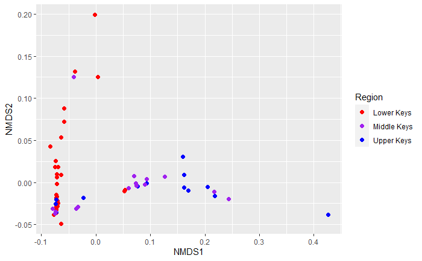

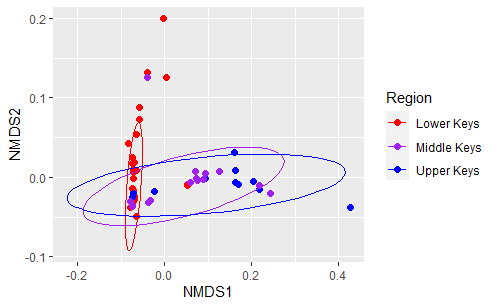

```r
#the only things to adjust for other datasets here is the color = "Region" and the scale_color_manual(). you could also leave them out and R will not color or just leave out the scale_color_manual() and R will choose the colors

print(pMDS)+stat_ellipse(aes(fill=Region)) #print the plot with 95% confidence ellipses
```

#### What is the stress value in nMDS?

The *stress* is the disagreement between the 2-D configuration and predicted values from the regression of distances in the initial configuration against the observed (measured) distances… so basically it’s a measure of how well the 2-d space represents the original multidimensional space. A good rule of thumb: stress < 0.05 provides an excellent representation in reduced dimensions, < 0.1 is great, < 0.2 is good/ok, and stress < 0.3 provides a poor representation.

A useful link for understanding nMDS with a different way to run the analysis in R: https://jonlefcheck.net/2012/10/24/nmds-tutorial-in-r/

### Betadisper

betadisper is a multivariate analogue of Levene’s test for homogeneity of variances. Non-euclidean distances between objects and group centroids are handled by reducing the original distances to principal coordinates.

#### What goes in/out:

in: the bray curtis disimilarity distances, the sample data, and the factor being compared (Region)

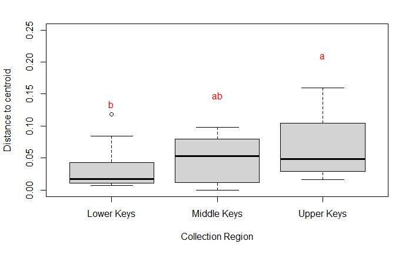

Supports the results of the nMDS analysis, though is slightly contradictory to the multiple PERMANOVA tests- only the lower and upper keys are significantly different.